# Warm Up - sf Tutorial

## 6.6 Areas

```r
st_area(Polygon1)
```

```
112457788 [m^2]
```

```r
st_area(Polygon2)
```

```
112449284 [m^2]
```

```r
Uruguay <- Uruguay %>% mutate(Areas = st_area(Uruguay)) %>% mutate(Areas = as.numeric(Areas))
```

## 6.7 Ceontroids

```r
MyCentroid <- st_centroid(Polygon1)
```

```
st_centroid assumes attributes are constant over geometries of x
```

```r
MyCentroid
```

```
Simple feature collection with 1 feature and 7 fields
geometry type:  POINT
dimension:      XY
bbox:           xmin: 581305.4 ymin: 6139145 xmax: 581305.4 ymax: 6139145
epsg (SRID):    32721
proj4string:    +proj=utm +zone=21 +south +datum=WGS84 +units=m +no_defs
  CALLE CRUCE TIPO ANIO NOM_CALLE         NOM_CRUCE                       ESQUINA
1  3564  3525 LEVE 2010 AV ITALIA HIPOLITO YRIGOYEN AV ITALIA Y HIPOLITO YRIGOYEN
                  geometry
1 POINT (581305.4 6139145)
```

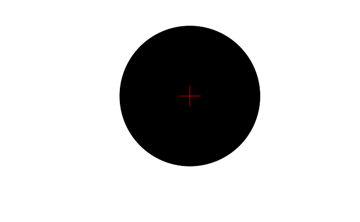

```r
plot(st_geometry(Polygon1), col = "black")
plot(st_geometry(MyCentroid), col = "red", pch = 3, cex = 4, add = TRUE)
```

```r
UruguayCentroids <- Uruguay %>% st_centroid()
```

```
st_centroid assumes attributes are constant over geometries of x
```

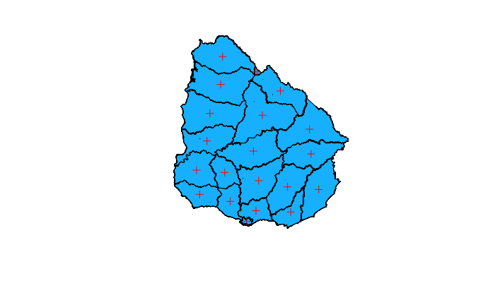

```r
plot(st_geometry(Uruguay), col = "deepskyblue1")
plot(st_geometry(UruguayCentroids), pch = 3, col = "red", add = TRUE)
```

## 6.8 Other Spatial Operations

If you want to see the full capabilities provided by *sf* you can check this [cheatsheet](https://github.com/rstudio/cheatsheets/blob/master/sf.pdf) or the [package vignettes](https://r-spatial.github.io/sf/articles/sf1.html)

# 7 Data Sources

All data used in this workflow was downloaded from **Open Source** [pltaforms](https://catalogodatos.gub.uy/dataset?res_format=SHP)

- Data in */montevideorural_shp* and */montevideourbano_shp* were retrieved from the Uruguay [Cátalogo dde datos abiertos](https://catalogodatos.gub.uy/dataset/shapes-del-parcelario-rural-y-urbano).
- Data in */Vectoriales_2011* were retrieved from [Instituto nacional de estadística](http://ine.gub.uy/mapas-vectoriales)
- Data in */Accidentes2006-2010* were taken from [Catálogo de datos abiertos](https://catalogodatos.gub.uy/dataset/accidentes-de-transito-montevideo)
- Data in */CyclingMontevideoData* were taken from [Catálogo de datos abiertos](https://catalogodatos.gub.uy/dataset/bicicircuitos-bicicletarios-estaciones-y-talleres-de-reparacion)
- Data in*/afe_estaciones* were taken from the [Geoportal](http://geoportal.mtop.gub.uy/geoservicios)

Another interesting soure in Uruguay is:

- [La Encuesta continua de hogares](http://www.ine.gub.uy/web/guest/encuesta-continua-de-hogares1)